# Teste para duas amostra dependentes e independentes

Rumenick Pereira da Silva

27 de março de 2019

## Teste para duas amostra dependentes (ou pareadas)

Suponha que Cássio não tinha uma referência da concentração de Alpha nas populações de doentes e sadios. Logo Cássio teria duas opções: construir uma referência (coletar a concentração de Alpha antes do tratamento) ou considera um grupo controle (grupo que receberia algum tipo de placebo ou não receberia nada). No primeiro caso, Cássio está fazendo duas medidas no mesmo pacientes em dois instantes de tempo diferentes. Esse tipo de mensuração gera o problema de dependência entre as duas amostras - antes e depois do tratamento.

```r
dados <- data.frame(id = rep(1:30, 2),
                    ordem = rep(sample(1:30), 2),
                    alpha = c(rnorm(n = 30, mean = 18, sd = 0.5), rnorm(n = 30, mean = 14, sd = 3)),
                    momento = rep(c("Antes", "Depois"), each = 30))
head(dados, n = 18)
```

```
##    id ordem    alpha momento
## 1   1     4 17.01914   Antes
## 2   2    24 18.71666   Antes
## 3   3    11 18.42029   Antes
## 4   4    23 18.90453   Antes
## 5   5    29 18.48179   Antes
## 6   6     2 17.68775   Antes
## 7   7    21 18.37746   Antes
## 8   8    12 17.78691   Antes
## 9   9    17 16.94677   Antes
## 10 10     5 17.96565   Antes
## 11 11    26 17.88200   Antes
## 12 12     3 18.22135   Antes
## 13 13    15 18.32900   Antes
## 14 14    22 18.20135   Antes
## 15 15    19 17.49179   Antes
## 16 16     9 18.00974   Antes
## 17 17     1 17.59232   Antes
## 18 18     7 18.45323   Antes
```

### Análise exploratória

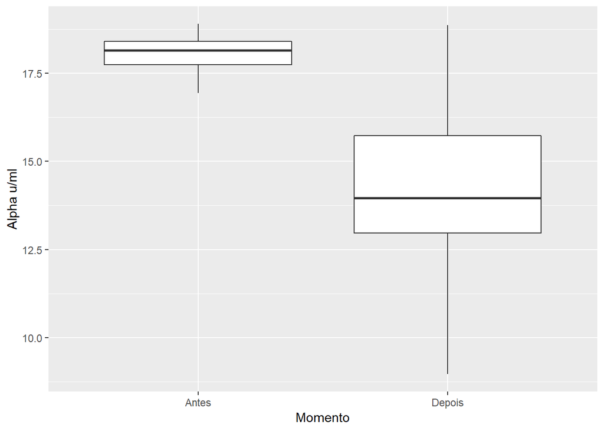

```r
dados %>%
  ggplot(aes(x = momento, y = alpha)) +
  geom_boxplot() +
  labs(x = "Momento", y = "Alpha u/ml")
```

```r
t.test(formula = alpha ~ momento, paired = TRUE, data = dados, alternative = "two.sided")
```

```
##
##  Paired t-test
##
## data:  alpha by momento
## t = 8.5391, df = 29, p-value = 2.087e-09
## alternative hypothesis: true difference in means is not equal to 0
## 95 percent confidence interval:
##  2.796046 4.557260
## sample estimates:
## mean of the differences
##                3.676653
```

## Teste para duas amostra independentes

### Análise exploratória

```r
dados <- data_frame(id = 1:28,
                    ordem = sample(1:28),
                    alpha = rnorm(n = 28, mean = 15, sd = 6)[ordem],
                    dosagem = factor(rep(c("Alta", "Baixa"),
                                         each = 14),
                                         levels = c("Baixa", "Alta"))[ordem])
dados
```

```
## # A tibble: 28 x 4
##       id ordem alpha dosagem
##    <int> <int> <dbl> <fct>
##  1     1    20 13.1  Baixa
##  2     2    27 17.1  Baixa
##  3     3    14  5.02 Alta
##  4     4    11 16.9  Alta
##  5     5    26  7.67 Baixa
##  6     6    23 14.6  Baixa
##  7     7    16 16.0  Baixa
##  8     8    10 23.6  Alta
##  9     9    28 17.8  Baixa
## 10    10     8 13.1  Alta
## # ... with 18 more rows
```

```r
dados %>%
  group_by(dosagem) %>%
  summarise("Média" = mean(alpha), "Desvio padrão" = sd(alpha), "Coeficiente de variação" = `Desvio padrão` / `Média` * 100)
```

```
## # A tibble: 2 x 4
##   dosagem Média `Desvio padrão` `Coeficiente de variação`
##   <fct>   <dbl>           <dbl>                     <dbl>
## 1 Baixa    14.3            4.10                      28.7
## 2 Alta     16.1            6.74                      41.8
```

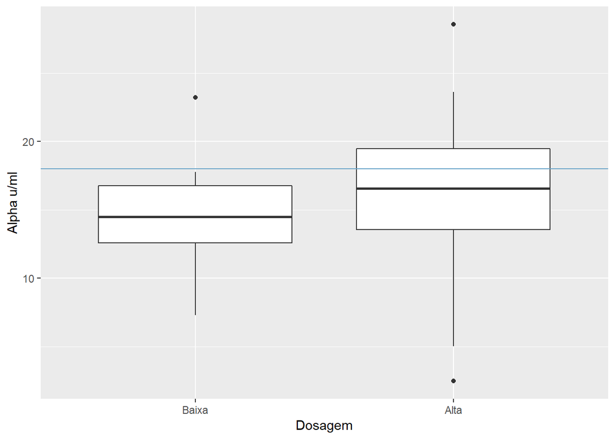

```r
dados %>%
  ggplot(aes(x = dosagem, y = alpha)) +
  geom_boxplot() +
  geom_abline(slope = 0, intercept = 18, colour = "#6aa4c8") +
  labs(y = "Alpha u/ml", x = "Dosagem")
```

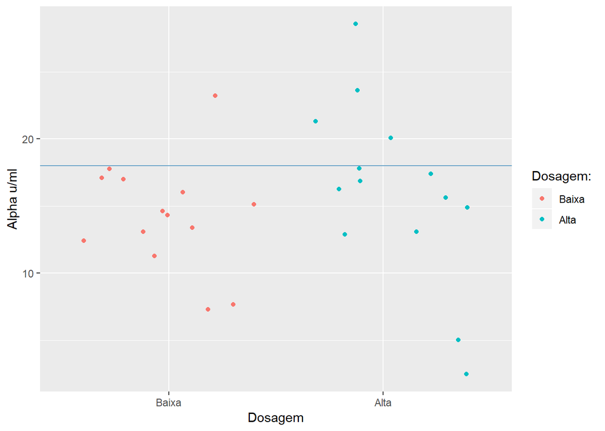

```r
dados %>%
  ggplot(aes(x = dosagem, y = alpha, colour = dosagem)) +
  geom_jitter() +
  geom_abline(slope = 0, intercept = 18, colour = "#6aa4c8") +
  labs(y = "Alpha u/ml", x = "Dosagem") +
  scale_color_discrete(name = "Dosagem:")
```

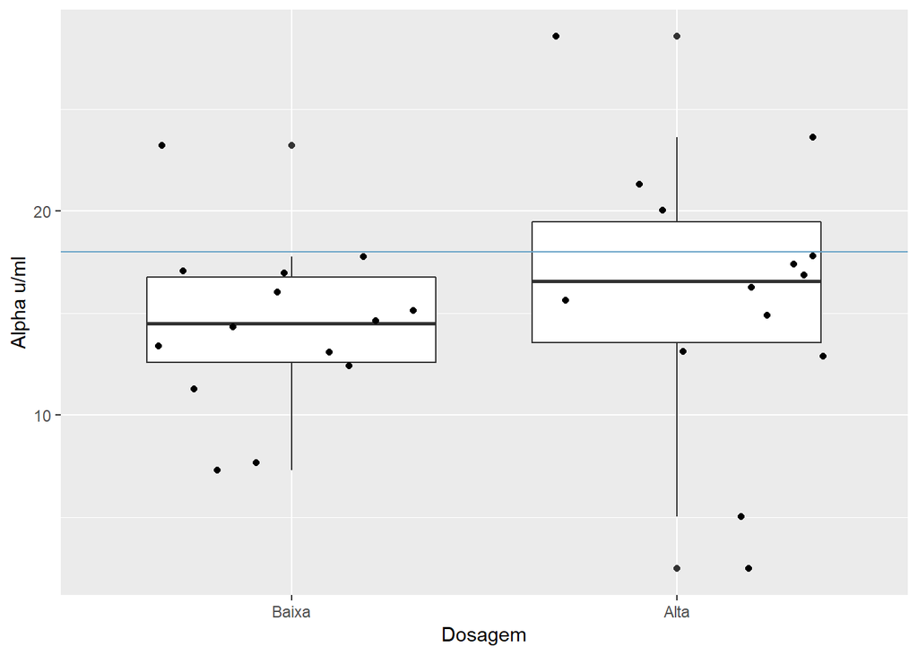

```r
dados %>%
  ggplot(aes(x = dosagem, y = alpha)) +
  geom_boxplot() +
  geom_jitter() +
  geom_abline(slope = 0, intercept = 18, colour = "#6aa4c8") +
  labs(y = "Alpha u/ml", x = "Dosagem")
```

### Checando a distribuição dos dados visualmente

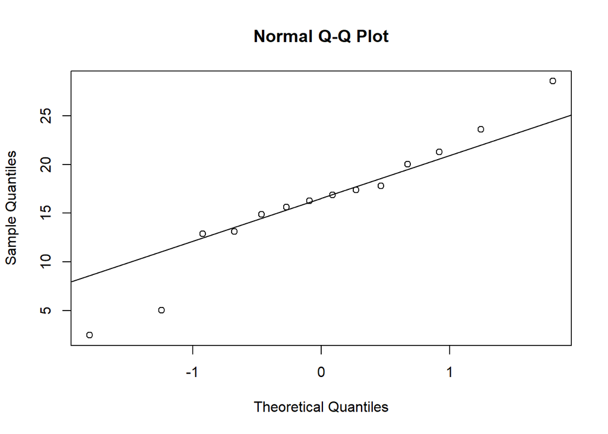

```r
qqnorm(y = dados$alpha[dados$dosagem == "Alta"])
qqline(y = dados$alpha[dados$dosagem == "Alta"])
```

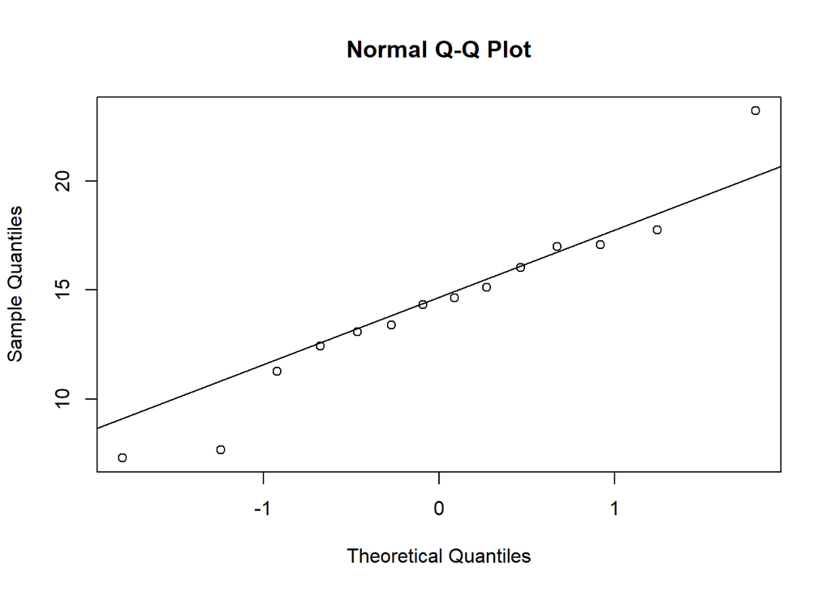

```r
qqnorm(y = dados$alpha[dados$dosagem == "Baixa"])
qqline(y = dados$alpha[dados$dosagem == "Baixa"])
```

## Checando a distribuição dos dados usando testes de hipóteses

```r
shapiro.test(dados$alpha[dados$dosagem == "Alta"])
```

```
##
##  Shapiro-Wilk normality test
##
## data:  dados$alpha[dados$dosagem == "Alta"]
## W = 0.95297, p-value = 0.6076
```

```r
shapiro.test(dados$alpha[dados$dosagem == "Baixa"])
```

```
##
##  Shapiro-Wilk normality test
##
## data:  dados$alpha[dados$dosagem == "Baixa"]
## W = 0.95803, p-value = 0.6906
```

### Teste de hipóteses sobre as médias de duas populações normais com variâncias iguais

$H_0$: $\mu_{Baixa} = \mu_{Alta}$ ou $\mu_{Baixa} - \mu_{Alta} = 0$.

$H_0$: $\mu_{Baixa} \neq \mu_{Alta}$ ou $\mu_{Baixa} - \mu_{Alta} = 0$;

```r
t.test(formula = alpha ~ dosagem, data = dados, var.equal = TRUE, alternative = "two.sided")
```

```
##
##  Two Sample t-test
##
## data:  alpha by dosagem
## t = -0.86691, df = 26, p-value = 0.3939
## alternative hypothesis: true difference in means is not equal to 0
## 95 percent confidence interval:
##  -6.159004  2.504986
## sample estimates:
## mean in group Baixa  mean in group Alta
##            14.30753            16.13454
```

Observação: este teste realiza a comparação das médias com a suposição que a variabilidade populacional de cada dosagem são iguais.

### Teste de hipóteses sobre as médias de duas populações normais com variâncias diferentes

$H_0$: $\mu_{Baixa} = \mu_{Alta}$ ou $\mu_{Baixa} - \mu_{Alta} = 0$.

$H_0$: $\mu_{Baixa} \neq \mu_{Alta}$ ou $\mu_{Baixa} - \mu_{Alta} = 0$;

```r
t.test(formula = alpha ~ dosagem, data = dados, var.equal = FALSE, alternative = "two.sided")
```

```
##
##  Welch Two Sample t-test
##
## data:  alpha by dosagem
## t = -0.86691, df = 21.467, p-value = 0.3956
## alternative hypothesis: true difference in means is not equal to 0
## 95 percent confidence interval:
##  -6.203963  2.549945
## sample estimates:
## mean in group Baixa  mean in group Alta
##            14.30753            16.13454
```

### Teste de hipóteses sobre duas variâncias de duas populações normais

$H_0$: $\sigma_{Baixa}^2 = \sigma_{Alta}^2$ ou $\frac{\sigma_{Baixa}^2}{\sigma_{Alta}^2} = 1$;

$H_0$: $\sigma_{Baixa}^2 \neq \sigma_{Alta}^2$ ou $\frac{\sigma_{Baixa}^2}{\sigma_{Alta}^2} = 1$.

```r
var.test(formula = alpha ~ dosagem, data = dados, alternative = "two.sided")
```

```
##
##  F test to compare two variances
##
## data:  alpha by dosagem
## F = 0.37031, num df = 13, denom df = 13, p-value = 0.08484
## alternative hypothesis: true ratio of variances is not equal to 1
## 95 percent confidence interval:
##  0.1188785 1.1535314
## sample estimates:
## ratio of variances
##          0.3703108
```

### Teste de hipóteses sobre duas proporções populacional

Assim como no exemplo com uma amostra, suponha que por algum motivo Cassio não esta preocupado com os valores exato da medida Alpha, porém ele deseja saber se a proporção de pessoas com valor de Alpha menor que 18 em ambas populações são iguais.

$H_0$: $p_{Baixa} = p_{Alta}$;

$H_1$: $p_{Baixa} \neq p_{Alta}$.

```r
dados <-
  dados %>%
  mutate(alpha_menor_18 = factor(ifelse(alpha < 18, "Sim", "Não"), levels = c("Sim", "Não")))
dados
```

```
## # A tibble: 28 x 5
##       id ordem alpha dosagem alpha_menor_18
##    <int> <int> <dbl> <fct>   <fct>
##  1     1    20 13.1  Baixa   Sim
##  2     2    27 17.1  Baixa   Sim
##  3     3    14  5.02 Alta    Sim
##  4     4    11 16.9  Alta    Sim
##  5     5    26  7.67 Baixa   Sim
##  6     6    23 14.6  Baixa   Sim
##  7     7    16 16.0  Baixa   Sim
##  8     8    10 23.6  Alta    Não
##  9     9    28 17.8  Baixa   Sim
## 10    10     8 13.1  Alta    Sim
## # ... with 18 more rows
```

```r
tab <- table(dados$dosagem, dados$alpha_menor_18)
prop.table(tab, margin = 1) * 100
```

```
##
##               Sim       Não
##   Baixa 92.857143  7.142857
##   Alta  71.428571 28.571429
```

```r
prop.test(tab)
```

```
##
##  2-sample test for equality of proportions with continuity
##  correction
##
## data:  tab
## X-squared = 0.97391, df = 1, p-value = 0.3237
## alternative hypothesis: two.sided
## 95 percent confidence interval:
##  -0.1295346  0.5581060
## sample estimates:
##    prop 1    prop 2
## 0.9285714 0.7142857
```

### Alternativas para a quebra de pressuposto de normalidade dos dados

```r
wilcox.test(formula = alpha ~ dosagem, data = dados, alternative = "two.sided")
```

```
##
##  Wilcoxon rank sum test
##
## data:  alpha by dosagem
## W = 71, p-value = 0.2273
## alternative hypothesis: true location shift is not equal to 0
```